# Green behavior and personality report

Lendi N. Joy

2/22/2021

# Homework 03

You will analyze data looking at the relationship between **green reputation** and three personality traits–**compassion**, **intellectual curiosity**, and **openness to experiences**. The dataset includes data from **students** and **non-students**.

## Load the data.

```r
dictionary <- readr::read_csv("green_dictionary.csv")
green_data <- readr::read_csv("green_data.csv")
```

## Load necessary libraries.

```r
library(dplyr)
```

```r
library(ggplot2)
```

## For your assignment, do the following.

### 1. Inspect the item responses (e.g., with graphs or by summarizing distinct values).

```
 Is anything unusual?
```

```r
green_data %>%
summary()
```

```
##       id                green1          green2         green3
##  Length:373         Min.   :1.000   Min.   :1.00   Min.   :1.000
##  Class :character   1st Qu.:3.000   1st Qu.:2.00   1st Qu.:3.000
##  Mode  :character   Median :4.000   Median :3.00   Median :4.000
##                     Mean   :3.476   Mean   :2.93   Mean   :3.797
##                     3rd Qu.:4.000   3rd Qu.:4.00   3rd Qu.:4.000
##                     Max.   :5.000   Max.   :5.00   Max.   :5.000
##                     NA's   :58      NA's   :58     NA's   :58
##      green4          green5          comp1             comp2
##  Min.   :1.000   Min.   :1.000   Min.   :-99.000   Min.   :-99.000
##  1st Qu.:3.000   1st Qu.:2.000   1st Qu.:  4.000   1st Qu.:  4.000
##  Median :3.000   Median :3.000   Median :  4.000   Median :  4.000
##  Mean   :3.238   Mean   :2.835   Mean   :  3.648   Mean   :  3.702
##  3rd Qu.:4.000   3rd Qu.:4.000   3rd Qu.:  4.000   3rd Qu.:  4.500
##  Max.   :5.000   Max.   :5.000   Max.   :  5.000   Max.   :  5.000
##  NA's   :58      NA's   :58      NA's   :86        NA's   :78
##      comp3           comp4             comp5             comp6
##  Min.   :1.000   Min.   :-99.000   Min.   :-99.000   Min.   :1.000
##  1st Qu.:4.000   1st Qu.:  4.000   1st Qu.:  4.000   1st Qu.:2.000
##  Median :4.000   Median :  4.000   Median :  4.000   Median :2.000
##  Mean   :4.267   Mean   :  3.691   Mean   :  3.319   Mean   :2.161
##  3rd Qu.:5.000   3rd Qu.:  4.000   3rd Qu.:  4.000   3rd Qu.:3.000
##  Max.   :5.000   Max.   :  5.000   Max.   :  5.000   Max.   :5.000
##  NA's   :77      NA's   :85        NA's   :88        NA's   :81
##      comp7            comp8             comp9             comp10
##  Min.   :-99.00   Min.   :-99.000   Min.   :-99.000   Min.   :-99.000
##  1st Qu.:  2.00   1st Qu.:  2.000   1st Qu.:  2.000   1st Qu.:  1.000
##  Median :  2.00   Median :  2.000   Median :  2.000   Median :  2.000
##  Mean   :  1.84   Mean   :  1.739   Mean   :  1.342   Mean   :  1.577
##  3rd Qu.:  3.00   3rd Qu.:  2.000   3rd Qu.:  2.000   3rd Qu.:  2.000
##  Max.   :  5.00   Max.   :  5.000   Max.   :  5.000   Max.   :  5.000
##  NA's   :86       NA's   :90        NA's   :89        NA's   :89
##      intel1           intel2            intel3            intel4
##  Min.   :-99.00   Min.   :-99.000   Min.   :-99.000   Min.   :-99.000
##  1st Qu.:  3.00   1st Qu.:  3.000   1st Qu.:  3.000   1st Qu.:  3.000
##  Median :  4.00   Median :  4.000   Median :  4.000   Median :  4.000
##  Mean   :  3.38   Mean   :  3.336   Mean   :  2.822   Mean   :  2.656
##  3rd Qu.:  4.00   3rd Qu.:  4.000   3rd Qu.:  4.000   3rd Qu.:  4.000
##  Max.   :  5.00   Max.   :  5.000   Max.   :  5.000   Max.   :  5.000
##  NA's   :78       NA's   :90        NA's   :86        NA's   :88
```

[output cut: 25 more lines]

```
##  Min.   :-99.000   Min.   :1.000   Min.   :1.000   Min.   :-99.00
##  1st Qu.:  2.000   1st Qu.:2.000   1st Qu.:2.000   1st Qu.:  2.00
##  Median :  3.000   Median :2.000   Median :2.000   Median :  2.00
##  Mean   :  2.274   Mean   :2.599   Mean   :2.568   Mean   :  2.36
##  3rd Qu.:  4.000   3rd Qu.:3.000   3rd Qu.:4.000   3rd Qu.:  4.00
##  Max.   :  5.000   Max.   :5.000   Max.   :5.000   Max.   :  5.00
##  NA's   :85        NA's   :84      NA's   :77      NA's   :90
##     student
##  Min.   :-99.000
##  1st Qu.:  1.000
##  Median :  2.000
##  Mean   :  1.309
##  3rd Qu.:  2.000
##  Max.   :  2.000
##  NA's   :95
```

Several variables appear to have missing values coded as -99, so we will remove those. We will also recode student into a factor variable.

```r
green_data <- na_if(green_data, "-99")
green_data$student <- recode_factor(green_data$student, '1' = "not student", '2' = "student")
summary(green_data)
```

```
##       id                green1          green2         green3
##  Length:373         Min.   :1.000   Min.   :1.00   Min.   :1.000
##  Class :character   1st Qu.:3.000   1st Qu.:2.00   1st Qu.:3.000
##  Mode  :character   Median :4.000   Median :3.00   Median :4.000
##                     Mean   :3.476   Mean   :2.93   Mean   :3.797
##                     3rd Qu.:4.000   3rd Qu.:4.00   3rd Qu.:4.000
##                     Max.   :5.000   Max.   :5.00   Max.   :5.000
##                     NA's   :58      NA's   :58     NA's   :58
##      green4          green5          comp1           comp2
##  Min.   :1.000   Min.   :1.000   Min.   :1.000   Min.   :1.000
##  1st Qu.:3.000   1st Qu.:2.000   1st Qu.:4.000   1st Qu.:4.000
##  Median :3.000   Median :3.000   Median :4.000   Median :4.000
##  Mean   :3.238   Mean   :2.835   Mean   :4.007   Mean   :4.051
##  3rd Qu.:4.000   3rd Qu.:4.000   3rd Qu.:4.000   3rd Qu.:4.750
##  Max.   :5.000   Max.   :5.000   Max.   :5.000   Max.   :5.000
##  NA's   :58      NA's   :58      NA's   :87      NA's   :79
##      comp3           comp4           comp5           comp6
##  Min.   :1.000   Min.   :1.000   Min.   :1.000   Min.   :1.000
##  1st Qu.:4.000   1st Qu.:4.000   1st Qu.:4.000   1st Qu.:2.000
##  Median :4.000   Median :4.000   Median :4.000   Median :2.000
##  Mean   :4.267   Mean   :4.049   Mean   :4.042   Mean   :2.161
##  3rd Qu.:5.000   3rd Qu.:4.000   3rd Qu.:4.000   3rd Qu.:3.000
##  Max.   :5.000   Max.   :5.000   Max.   :5.000   Max.   :5.000
##  NA's   :77      NA's   :86      NA's   :90      NA's   :81
##      comp7           comp8           comp9           comp10
##  Min.   :1.000   Min.   :1.000   Min.   :1.000   Min.   :1.000
##  1st Qu.:2.000   1st Qu.:2.000   1st Qu.:2.000   1st Qu.:1.000
##  Median :2.000   Median :2.000   Median :2.000   Median :2.000
##  Mean   :2.192   Mean   :2.096   Mean   :2.053   Mean   :1.933
##  3rd Qu.:3.000   3rd Qu.:2.000   3rd Qu.:2.000   3rd Qu.:2.000
##  Max.   :5.000   Max.   :5.000   Max.   :5.000   Max.   :5.000
##  NA's   :87      NA's   :91      NA's   :91      NA's   :90
##      intel1          intel2          intel3          intel4
##  Min.   :1.000   Min.   :1.000   Min.   :1.000   Min.   :1.000
##  1st Qu.:3.000   1st Qu.:3.000   1st Qu.:3.000   1st Qu.:3.000
##  Median :4.000   Median :4.000   Median :4.000   Median :4.000
##  Mean   :3.728   Mean   :3.699   Mean   :3.537   Mean   :3.375
##  3rd Qu.:4.000   3rd Qu.:4.000   3rd Qu.:4.000   3rd Qu.:4.000
##  Max.   :5.000   Max.   :5.000   Max.   :5.000   Max.   :5.000
##  NA's   :79      NA's   :91      NA's   :88      NA's   :90
```

[output cut: 17 more lines]

```
##  Min.   :1.000   Min.   :1.00   Min.   :1.00   Min.   :1.000   Min.   :1.000
##  1st Qu.:3.000   1st Qu.:3.00   1st Qu.:3.00   1st Qu.:3.000   1st Qu.:2.000
##  Median :4.000   Median :4.00   Median :4.00   Median :4.000   Median :3.000
##  Mean   :3.749   Mean   :3.92   Mean   :3.83   Mean   :3.592   Mean   :2.983
##  3rd Qu.:4.000   3rd Qu.:5.00   3rd Qu.:4.00   3rd Qu.:4.000   3rd Qu.:4.000
##  Max.   :5.000   Max.   :5.00   Max.   :5.00   Max.   :5.000   Max.   :5.000
##  NA's   :90      NA's   :86     NA's   :90     NA's   :86      NA's   :87
##      open8           open9           open10            student
##  Min.   :1.000   Min.   :1.000   Min.   :1.00   not student: 91
##  1st Qu.:2.000   1st Qu.:2.000   1st Qu.:2.00   student    :186
##  Median :2.000   Median :2.000   Median :2.00   NA's       : 96
##  Mean   :2.599   Mean   :2.568   Mean   :2.72
##  3rd Qu.:3.000   3rd Qu.:4.000   3rd Qu.:4.00
##  Max.   :5.000   Max.   :5.000   Max.   :5.00
##  NA's   :84      NA's   :77      NA's   :91
```

### 2. Compute total scores for the four scales.

Recode variables as needed. [^1]

```r
green_data_comp <- green_data %>%
   rowwise() %>%
  mutate(across(c(green2, comp6:comp10, intel7:intel10, open7:open10), ~(6 - .x))) %>%
  mutate(greenM = mean(c_across(starts_with("g")), na.rm = TRUE),
         compM = mean(c_across(starts_with("c")), na.rm = TRUE),
         intelM = mean(c_across(intel1:intel10), na.rm = TRUE),
         openM = mean(c_across(starts_with("o")), na.rm = TRUE)) %>%
  ungroup()
```

Now let’s take a look at the new dataframe.

```r
green_data_comp
```

```
## # A tibble: 373 x 41
##    id    green1 green2 green3 green4 green5 comp1 comp2 comp3 comp4 comp5 comp6
##    <chr>  <dbl>  <dbl>  <dbl>  <dbl>  <dbl> <dbl> <dbl> <dbl> <dbl> <dbl> <dbl>
##  1 9099       4      4      5      4      3     2     5     4     4     2     4
##  2 6275       3      1      3      3      1     4     5     4     5     5     5
##  3 8116       4      4      5      4      3     4     5     5     4     5     5
##  4 8586       4      3      5      4      3     4     5     5     4     5     5
##  5 0406       3      4      4      4      4     4     4     4     4     4     4
##  6 5645       4      3      4      4      3     5     5     5     4     4     4
##  7 3788       1      5      1      1      1     3     3     3     3     3     3
##  8 8424       4      3      2      2      2     1     1     1     2     2     2
##  9 8450       4      4      3      5      2     4     4     4     4     4     5
## 10 0512       4      4      5      5      4     5     2     5     4     2     4
## # ... with 363 more rows, and 29 more variables: comp7 <dbl>, comp8 <dbl>,
## #   comp9 <dbl>, comp10 <dbl>, intel1 <dbl>, intel2 <dbl>, intel3 <dbl>,
## #   intel4 <dbl>, intel5 <dbl>, intel6 <dbl>, intel7 <dbl>, intel8 <dbl>,
## #   intel9 <dbl>, intel10 <dbl>, open1 <dbl>, open2 <dbl>, open3 <dbl>,
## #   open4 <dbl>, open5 <dbl>, open6 <dbl>, open7 <dbl>, open8 <dbl>,
## #   open9 <dbl>, open10 <dbl>, student <fct>, greenM <dbl>, compM <dbl>,
## #   intelM <dbl>, openM <dbl>
```

### 3. Rescale the variables so that they go from 0-100 instead of the original range.

Name the rescaled variables `*_pomp`. [^2]

```r
green_data_pomp <- select(green_data_comp, c(id, student:openM)) %>%
 rowwise() %>%
  mutate(across(c(greenM:openM), ~((.x - 1) / (5 - 1) * 100),
                .names = "{.col}_pomp")) %>%
  ungroup()
green_data_pomp
```

```
## # A tibble: 373 x 10
##    id    student    greenM compM intelM openM greenM_pomp compM_pomp intelM_pomp
##    <chr> <fct>       <dbl> <dbl>  <dbl> <dbl>       <dbl>      <dbl>       <dbl>
##  1 9099  student       4     3.7    2.8  3.5          75        67.5        45.0
##  2 6275  student       2.2   4.8    3.5  3.1          30.       95          62.5
##  3 8116  student       4     4.4    3.6  3.9          75        85.         65
##  4 8586  student       3.8   4.6    3    3.9          70        90.0        50
##  5 0406  student       3.8   4      3.7  3.7          70        75          67.5
##  6 5645  student       3.6   4.2    3.8  3.8          65        80          70
##  7 3788  student       1.8   3      3    3            20        50          50
##  8 8424  student       2.6   1.9    4.3  1.8          40        22.5        82.5
##  9 8450  not stude~    3.6   4.2    4    4.33         65        80          75
## 10 0512  student       4.4   3.8    3.7  3.8          85.       70          67.5
## # ... with 363 more rows, and 1 more variable: openM_pomp <dbl>
```

### 4. Make plots that illustrate the distributions of the 4 POMP-scored variables.

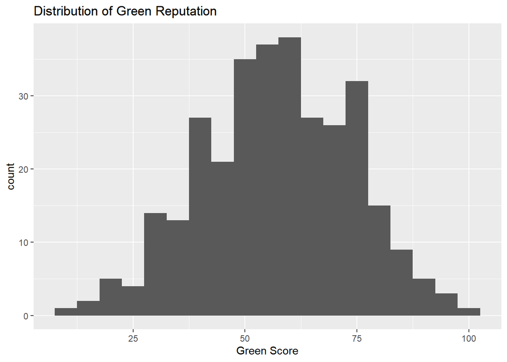

```r
green_data_pomp %>%
ggplot(
  aes(greenM_pomp)) +
  geom_histogram(binwidth = 5) +
  xlab("Green Score") +
  ggtitle("Distribution of Green Reputation")
```

Green reputation score appears to be relatively normally distributed.

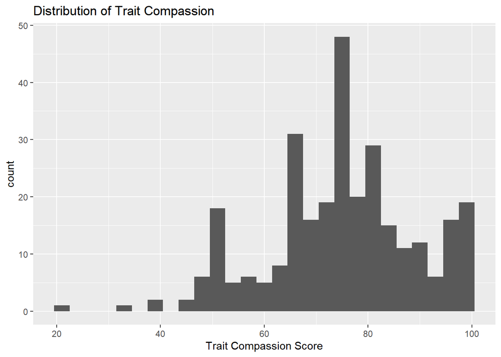

```r
green_data_pomp %>%
ggplot(
  aes(compM_pomp)) +
  geom_histogram(binwidth = 3) +
  xlab("Trait Compassion Score") +
  ggtitle("Distribution of Trait Compassion")
```

Trait compassion has a slight left skew, but overall appears to be normally distributed. There may possibly a few outliers to examine.

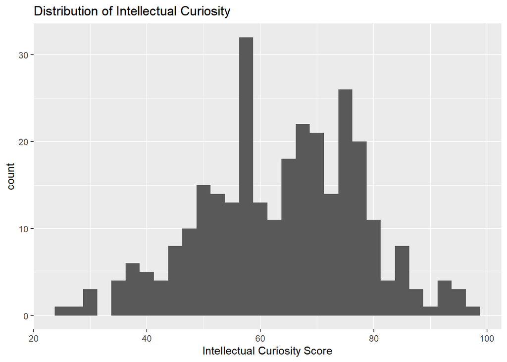

```r
green_data_pomp %>%
ggplot(
  aes(intelM_pomp)) +
  geom_histogram(binwidth = 2.5) +
  xlab("Intellectual Curiosity Score") +
  ggtitle("Distribution of Intellectual Curiosity")
```

Trait intellectual curiosity appears normally distributed.

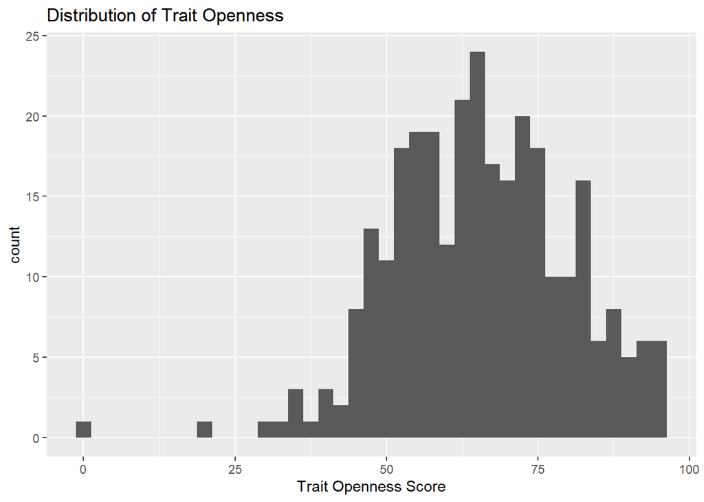

```r
green_data_pomp %>%
ggplot(
  aes(openM_pomp)) +
  geom_histogram(binwidth = 2.5) +
  xlab("Trait Openness Score") +
  ggtitle("Distribution of Trait Openness")
```

Trait openness appears mostly normally distributed. There may be a few outliers on the lower end to examine.

### 5. Make scatterplots showing the relationships between **green reputation** and each personality trait.

```
 Include trend lines for **students** and **non-students**.
 What do these plots show?
```

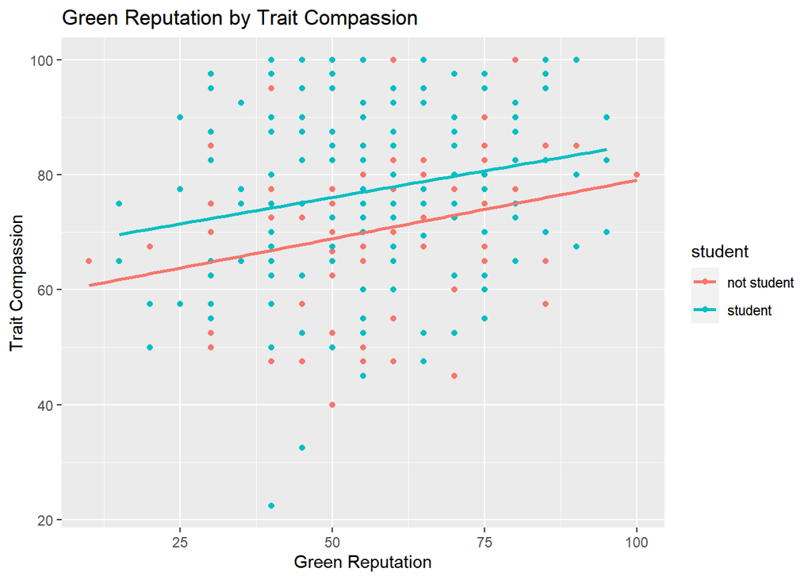

```r
green_data_pomp %>%
  filter(!is.na(student)) %>%
    ggplot(aes(greenM_pomp, compM_pomp, color = student)) +
  geom_point() +
  geom_smooth(method = "lm", se = FALSE) +
  ggtitle("Green Reputation by Trait Compassion") +
  xlab("Green Reputation") +
  ylab("Trait Compassion")
```

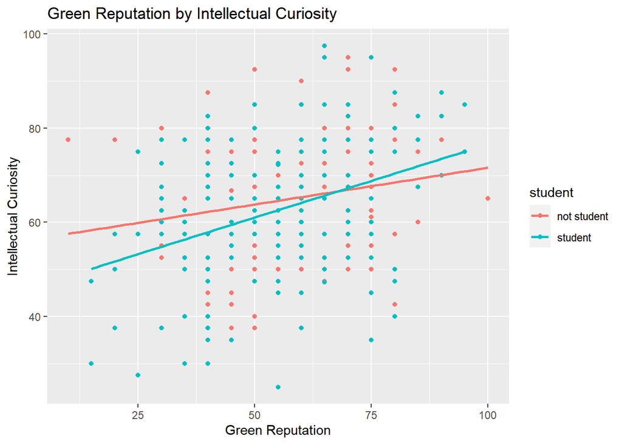

```r
green_data_pomp %>%
  filter(!is.na(student)) %>%
    ggplot(aes(greenM_pomp, intelM_pomp, color = student)) +
  geom_point() +
  geom_smooth(method = "lm", se  =  FALSE) +
  ggtitle("Green Reputation by Intellectual Curiosity") +
  xlab("Green Reputation") +
  ylab("Intellectual Curiosity")
```

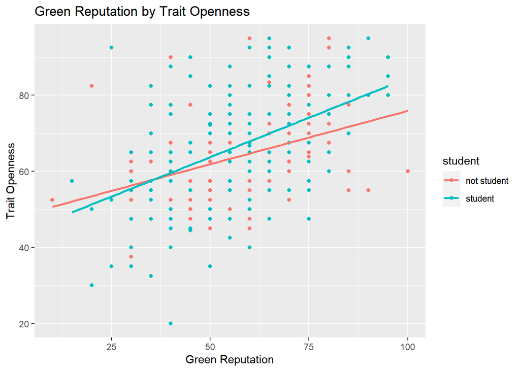

```r
green_data_pomp %>%
  filter(!is.na(student)) %>%
    ggplot(aes(greenM_pomp, openM_pomp, color = student)) +
  geom_point() +
  geom_smooth(method = "lm", se = FALSE) +
  ggtitle("Green Reputation by Trait Openness") +
  xlab("Green Reputation") +
  ylab("Trait Openness")
```

Students appear to be slightly higher on trait openness than non-students. Although it appears that there may be an interaction effect of student status on the relationship between trait openness and green reputation such that non-students score higher than students on trait openness when green reputation is low, but lower on trait openness when green reputation is higher.

### 6. Compare **green reputation** for students and non-students using a **rainfall plot** (bar + density + data points).

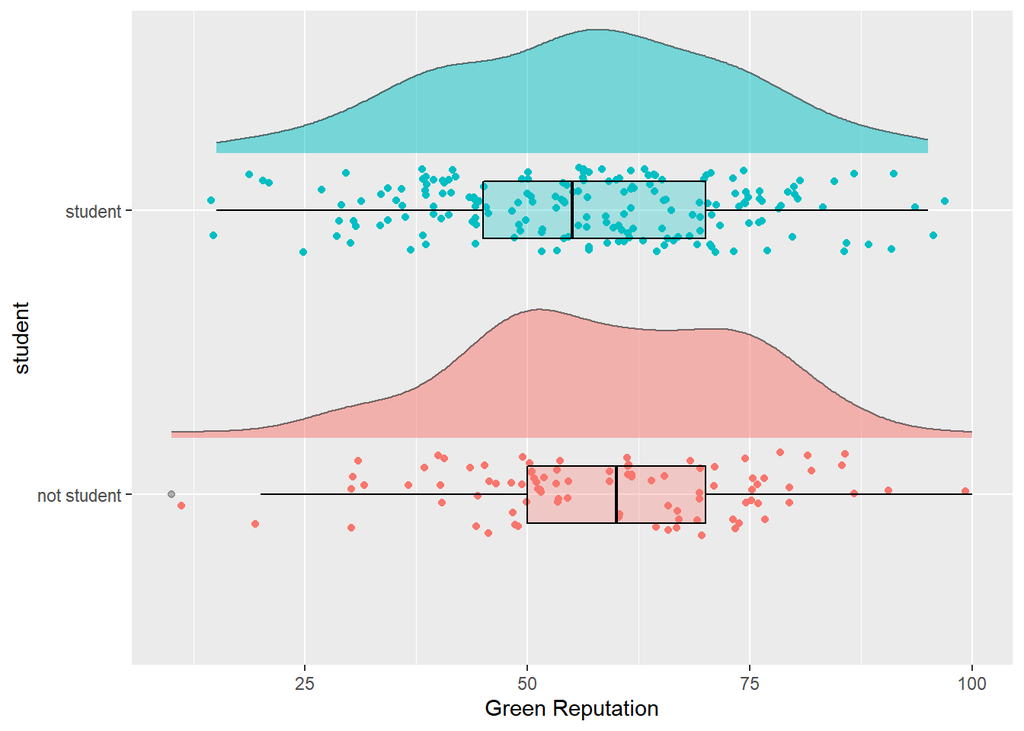

```r
green_data_pomp %>%
  filter(!is.na(student)) %>%
  ggplot() +
  aes(y = student, x = greenM_pomp, fill = student, color = student) +
  geom_jitter(height = .15) +
  geom_boxplot(color = "black", alpha = .3, width = .2, size = .4) +
  xlab("Green Reputation") +
  theme(legend.position = "none") +
  ggdist::stat_slab(height = .5, color = "black", size = .4,
                    alpha = .5,
                    position = position_nudge(y = .2))
```

### 7. Compute a summary table of means, SDs, medians, minima, and maxima for the four total scores for students and non-students.

We can create a summary table like this:

```r
green_data_pomp %>%
  filter(!is.na(student)) %>%
  group_by(student) %>%
  summarize(across(c(greenM_pomp:openM_pomp),
                   list(mean = ~mean(., na.rm = TRUE), sd = ~sd(., na.rm = TRUE),
                        meadian = ~median(., na.rm = TRUE), min = ~min(., na.rm = TRUE),
                        max = ~max(., na.rm = TRUE))))
```

```
## # A tibble: 2 x 21
##   student     greenM_pomp_mean greenM_pomp_sd greenM_pomp_meadi~ greenM_pomp_min
## * <fct>                  <dbl>          <dbl>              <dbl>           <dbl>
## 1 not student             58.7           16.5                60             10.0
## 2 student                 56.4           17.1                55.            15.
## # ... with 16 more variables: greenM_pomp_max <dbl>, compM_pomp_mean <dbl>,
## #   compM_pomp_sd <dbl>, compM_pomp_meadian <dbl>, compM_pomp_min <dbl>,
## #   compM_pomp_max <dbl>, intelM_pomp_mean <dbl>, intelM_pomp_sd <dbl>,
## #   intelM_pomp_meadian <dbl>, intelM_pomp_min <dbl>, intelM_pomp_max <dbl>,
## #   openM_pomp_mean <dbl>, openM_pomp_sd <dbl>, openM_pomp_meadian <dbl>,
## #   openM_pomp_min <dbl>, openM_pomp_max <dbl>
```

This works, but it doesn’t look the best…

So, let’s create a nicer table for the HTML page.

1. First, load the ‘table1’ package.

```r
library(table1)
```

2. Next, we will create variable labels for a more aesthetically pleasing look.

```r
label(green_data_pomp$greenM_pomp) <- "Green Reputation"
label(green_data_pomp$compM_pomp) <- "Compassion"
label(green_data_pomp$intelM_pomp) <- "Intellectual Curiosity"
label(green_data_pomp$openM_pomp) <- "Openness to Experience"
```

3. Finally, we will compute the summary table and group the results by student status.

```r
table1(~greenM_pomp + compM_pomp + intelM_pomp + openM_pomp | student,
       data = green_data_pomp, render.missing = NULL)
```

|  | not student (N=91) | student (N=186) | Overall (N=373) |
| --- | --- | --- | --- |
| Green Reputation |  |  |  |
| Mean (SD) | 58.7 (16.5) | 56.4 (17.1) | 57.1 (16.9) |
| Median [Min, Max] | 60.0 [10.0, 100] | 55.0 [15.0, 95.0] | 55.0 [10.0, 100] |
| Compassion |  |  |  |
| Mean (SD) | 70.7 (13.1) | 77.3 (14.6) | 75.0 (14.3) |
| Median [Min, Max] | 72.5 [40.0, 100] | 76.3 [22.5, 100] | 75.0 [22.5, 100] |
| Intellectual Curiosity |  |  |  |
| Mean (SD) | 65.1 (13.7) | 63.0 (14.2) | 63.7 (14.0) |
| Median [Min, Max] | 67.5 [37.5, 95.0] | 65.0 [25.0, 97.5] | 65.0 [25.0, 97.5] |
| Openness to Experience |  |  |  |
| Mean (SD) | 64.3 (12.5) | 66.4 (14.8) | 65.5 (14.5) |
| Median [Min, Max] | 62.5 [37.5, 95.0] | 65.8 [20.0, 95.0] | 65.0 [0, 95.8] |

[^1]: I wasn’t sure if this should be a sum or mean and since ‘id’ starts with “i”, we had to use a different method to compute the composite score.
[^2]: I wasn’t sure if this should be all variables or just the composite variables.